# Bài thực hành số 2 — Web3.py & Ape Framework

*> Geth trên Windows thường dùng HTTP `http://127.0.0.1:8545` thay vì IPC `/tmp/geth.ipc` (Linux/Mac). IPC Windows (nếu bật): `\\.\pipe\geth.ipc`.*

# A — Web3.py + Ganache

## i. Thiết lập môi trường

### Cài Web3.py

```python
%pip install web3
```

[output not shown]

[output cut: 151 more lines]

[output not shown]

### Cài / mở Ganache

- Tải: https://archive.trufflesuite.com/ganache/
- Tạo **New Workspace** (ví dụ tên `IS355-BC`), bấm **Start**.
- RPC server: thường `http://127.0.0.1:7545`.

### Ảnh minh họa

Hình 1 — trang web Ganache:

[figure not shown]

Hình 2 — màn hình giới thiệu:

[figure not shown]

Hình 3 — Quickstart:

[figure not shown]

Hình 4 — Workspace:

[figure not shown]

Hình 5 — Accounts (mỗi account ~100 ETH, block 0):

[figure not shown]

### Yêu cầu báo cáo (Ganache tabs)

Chụp và mô tả ngắn các tab: **Server**, **Accounts & keys**, **Chain**, **Advanced**, **About**.

### Các tab cấu hình Ganache (workspace `IS355-BC`)

Yêu cầu đề: chụp và giới thiệu các tab **Server**, **Accounts & keys**, **Chain**, **Advanced**, **About**.

#### Tab Server

[figure not shown]

- **Hostname:** `127.0.0.1`
- **Port:** `7545` → RPC `http://127.0.0.1:7545`
- **Network ID:** `5777`
- **Automine:** bật
- **Error on transaction failure:** bật
- Chain forking: disabled (chỉ đổi khi tạo workspace mới)

#### Tab Accounts & Keys

[figure not shown]

- Với workspace đã tạo: **không sửa được** accounts/keys (thông báo *Accounts can only be updated when creating a new workspace*).
- Muốn đổi số account / mnemonic / ETH ban đầu → tạo workspace mới.
- Danh sách account xem ở màn hình Accounts chính (Hình 5).

#### Tab Chain

[figure not shown]

- **Gas Price:** `20000000000` wei (= 20 gwei)
- **Hardfork:** `Merge`
- Gas limit chỉ đổi được lúc tạo workspace mới

#### Tab Advanced

[figure not shown]

- **Output logs to file:** tắt
- **Verbose logs:** tắt
- **Google Analytics:** bật (global, không lưu address/private key)

#### Tab About

[figure not shown]

- **Version:** Ganache **v2.7.1** (Truffle)

| Tab | Nội dung chính (máy này) |
| --- | --- |
| **Server** | `127.0.0.1:7545`, Network ID `5777`, Automine ON |
| **Accounts & keys** | Chỉ xem được khi tạo workspace mới; account hiện tại xem Hình 5 |
| **Chain** | Gas price `20 gwei`, Hardfork `Merge` |
| **Advanced** | Logging OFF; Analytics ON |
| **About** | v2.7.1 |

## ii. Tạo account + chuyển ETH

> Bản cài Geth không có `clef.exe` → dùng `geth account new` (tạo keystore tương đương).

### Cách làm

```
cd D:\Study\IS355\TH\w2
mkdir my_keystore -Force
D:\Tools\Geth\geth.exe account new --keystore my_keystore
```

[figure not shown]

### Chuyển 10 ETH trong console Geth

**Không** dùng `"0xDIA_CHI_MOI"` (placeholder). Dán địa chỉ thật:

```
eth.sendTransaction({from: eth.accounts[0], to: "0x69f1Aeba4Bf643A4C9533a6Fd5Eb64c8fC78fD5f", value: web3.toWei(10, "ether")})
```

```
web3.fromWei(eth.getBalance("0x69f1Aeba4Bf643A4C9533a6Fd5Eb64c8fC78fD5f"), "ether")
```

Ket qua chuyen 10 ETH (balance = 10):

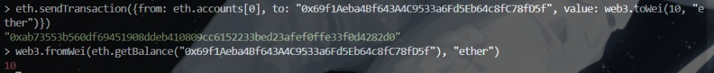

Nếu dán nhầm placeholder → lỗi `invalid address`:

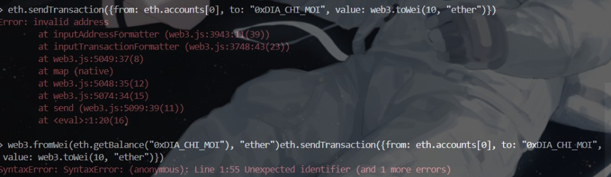

```python
# hello_web3.py — kết nối Ganache & đọc balance
# Chạy cell này SAU KHI đã mở Ganache (RPC :7545)
from web3 import Web3

w3 = Web3(Web3.HTTPProvider("http://127.0.0.1:7545"))
print(f"Python script is connected? {w3.is_connected()}")

# Account INDEX 3 trên Ganache IS355-BC
ACCOUNT_3 = Web3.to_checksum_address("0x0527609ad5e731bb3752821063D6f57c7602cbbE")  # INDEX 3

account_balance = w3.eth.get_balance(ACCOUNT_3)
print(f"The balance of the 3rd account is {account_balance}")
print(f"Balance in ETH = {w3.from_wei(account_balance, 'ether')}")
print("Ghi nhớ: 1 ETH = 1_000_000_000_000_000_000 wei")
```

```
Python script is connected? True
The balance of the 3rd account is 100000000000000000000
Balance in ETH = 100
Ghi nhớ: 1 ETH = 1_000_000_000_000_000_000 wei
```

### Private key account #3 (INDEX 3)

[figure not shown]

- Address: 0x0527609ad5e731bb3752821063D6f57c7602cbbE
- Private key: (xem ảnh — **chỉ dùng trên Ganache local**)

## iii. Chuyển ETH: account #3 → account #6

### Các bước chương trình

1. Kết nối RPC Ganache.
2. Lấy `private_key` + `address` người gửi (#3), `address` người nhận (#6).
3. `amount = to_wei(...)`; lấy `nonce`.
4. Tạo dict `transaction` (`from`, `to`, `value`, `gas`, `gasPrice`, `nonce`).
5. `sign_transaction` → `send_raw_transaction` → (tuỳ chọn) chờ receipt.
6. In balance trước/sau để đối chiếu trên Ganache.

#### Bước 1 — Kết nối Ganache + khai báo account

```python
# transfer — account INDEX 3 -> INDEX 6
from web3 import Web3

w3 = Web3(Web3.HTTPProvider("http://127.0.0.1:7545"))
assert w3.is_connected(), "Mo Ganache truoc (http://127.0.0.1:7545)"

sender_private_key = "0x6552742db604c1cad2ebda4f5ba15a777999581d3a179d7e6c4a0b0950f61601"
sender_address = Web3.to_checksum_address("0x0527609ad5e731bb3752821063D6f57c7602cbbE")  # INDEX 3
recipient_address = Web3.to_checksum_address("0xb3233773DfB70B47f5Af0702392d84A1bE9Ed67F")  # INDEX 6

# De bai: 5 wei. Hinh 7: doi thanh Web3.to_wei(5, "ether")
amount = Web3.to_wei(5, "wei")
print("connected:", w3.is_connected())
print("sender   :", sender_address)
print("recipient:", recipient_address)
print("amount   :", amount, "wei")
```

```
connected: True
sender   : 0x0527609ad5e731bb3752821063D6f57c7602cbbE
recipient: 0xb3233773DfB70B47f5Af0702392d84A1bE9Ed67F
amount   : 5 wei
```

#### Bước 2 — Balance **trước** khi chuyển

```python
print("=== BEFORE ===")
print("sender   :", w3.from_wei(w3.eth.get_balance(sender_address), "ether"), "ETH")
print("recipient:", w3.from_wei(w3.eth.get_balance(recipient_address), "ether"), "ETH")
```

```
=== BEFORE ===
sender   : 100 ETH
recipient: 100 ETH
```

#### Bước 3 — Tạo transaction (`gas`, `gasPrice`, `nonce`)

```python
transaction = {
    "from": sender_address,
    "to": recipient_address,
    "value": amount,
    "gas": 21000,  # transfer thuong
    "gasPrice": Web3.to_wei("50", "gwei"),
    "nonce": w3.eth.get_transaction_count(sender_address),
}

print("=== TRANSACTION ===")
for k, v in transaction.items():
    print(f"  {k}: {v}")
```

```
=== TRANSACTION ===
  from: 0x0527609ad5e731bb3752821063D6f57c7602cbbE
  to: 0xb3233773DfB70B47f5Af0702392d84A1bE9Ed67F
  value: 5
  gas: 21000
  gasPrice: 50000000000
  nonce: 0
```

#### Bước 4 — Ký tx + gửi lên chain

```python
signed = w3.eth.account.sign_transaction(transaction, sender_private_key)
raw = getattr(signed, "raw_transaction", None) or signed.rawTransaction
tx_hash = w3.eth.send_raw_transaction(raw)
receipt = w3.eth.wait_for_transaction_receipt(tx_hash)
print("tx hash:", tx_hash.hex())
print("status :", receipt["status"], "(1=success)")
print("gasUsed:", receipt["gasUsed"])
```

```
tx hash: 3e34b0a93aad3714166c95ecc51f786cf3700422c40c3a9d15e252ee84a53b29
status : 1 (1=success)
gasUsed: 21000
```

#### Bước 5 — Balance **sau** khi chuyển + phí gas

```python
print("=== AFTER ===")
print("tx hash :", tx_hash.hex())
print("status  :", receipt["status"], "(1=success)")
print("gasUsed :", receipt["gasUsed"])
print("phi uoc tinh (wei):", receipt["gasUsed"] * transaction["gasPrice"])
print("sender   :", w3.from_wei(w3.eth.get_balance(sender_address), "ether"), "ETH")
print("recipient:", w3.from_wei(w3.eth.get_balance(recipient_address), "ether"), "ETH")
```

```
=== AFTER ===
tx hash : 3e34b0a93aad3714166c95ecc51f786cf3700422c40c3a9d15e252ee84a53b29
status  : 1 (1=success)
gasUsed : 21000
phi uoc tinh (wei): 1050000000000000
sender   : 99.998949999999999995 ETH
recipient: 100.000000000000000005 ETH
```

#### Kết quả trên Ganache (sau khi transfer)

Tab **BLOCKS** — Current Block = 1, Block 1 dùng **21000 gas**, có 1 transaction:

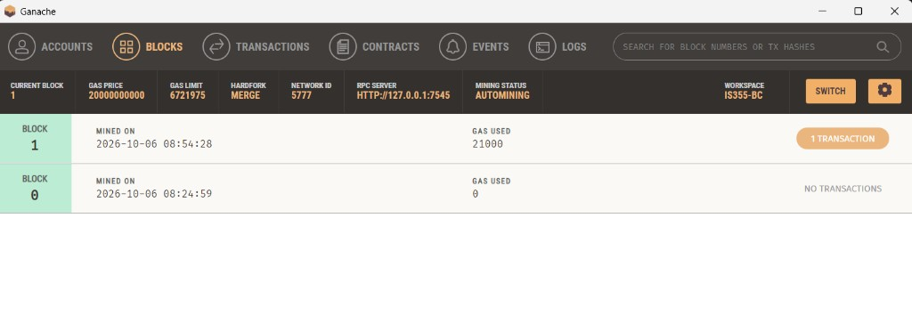

Chi tiết **BLOCK 1** — VALUE TRANSFER 5 wei, INDEX 3 → INDEX 6:

[figure not shown]

- **TX Hash:** `0x3e34b0a93aad3714166c95ecc51f786cf3700422c40c3a9d15e252ee84a53b29`
- **From:** `0x0527609ad5e731bb3752821063D6f57c7602cbbE` (INDEX 3)
- **To:** `0xb3233773DfB70B47f5Af0702392d84A1bE9Ed67F` (INDEX 6)
- **Gas Used:** `21000` | **Value:** `5` wei

### Giải thích nhanh `gas` & `gasPrice`

- **`gas = 21000`**: hạn mức tối đa cho simple transfer (khớp Gas Used trên Ganache).
- **`gasPrice`**: giá mỗi gas; trên Ganache automine thường không quan trọng thứ tự.
- **Phí thực tế** ≈ `gasUsed * gasPrice` = `21000 * 50 gwei`.
- Sender mất thêm phí gas ngoài số ETH/wei chuyển.

# B — Ape Framework

## i. Cài đặt & `ape init`

#### Bước 1 — Cài `eth-ape`

```python
# Cài Ape Framework
%pip install eth-ape
```

[output not shown]

[output cut: 115 more lines]

[output not shown]

[output not shown]

#### Bước 2 — Kiểm tra version

```python
!ape --version
```

```
'ape' is not recognized as an internal or external command,
operable program or batch file.
```

#### Bước 3 — Tạo project (`ape init`)

```python
# Tao project Ape (co the hoi ten project — nhap Bai02)
# Neu dang o TH/w2 va da co san contracts/scripts thi bo qua buoc nay
!ape init
```

```
'ape' is not recognized as an internal or external command,
operable program or batch file.
```

#### Bước 4 — Liệt kê cấu trúc thư mục sau `ape init`

```python
from pathlib import Path

root = Path(".")
print("CWD:", root.resolve())
print()
for p in sorted(root.iterdir()):
    kind = "dir " if p.is_dir() else "file"
    print(f"  [{kind}] {p.name}")

# Cac thu muc thuong gap
for name in ["contracts", "scripts", "tests", "ape-config.yaml", ".build"]:
    print(f"  exists {name}? -> {(root / name).exists()}")
```

[output not shown]

#### Bước 5 — Plugin Vyper

```python
!ape plugins list
```

```
'ape' is not recognized as an internal or external command,
operable program or batch file.
```

```python
# Cai plugin Vyper neu chua co
!ape plugins install vyper
```

```
'ape' is not recognized as an internal or external command,
operable program or batch file.
```

```python
# Kiem tra lai
!ape plugins list
```

```
'ape' is not recognized as an internal or external command,
operable program or batch file.
```

## ii. Contract `SimpleStorage.vy`

```python
# Doc file contracts/SimpleStorage.vy (da tach rieng)
from pathlib import Path

p = Path("contracts/SimpleStorage.vy")
assert p.exists(), f"Chua co {p.resolve()} — kiem tra thu muc TH/w2"
print(f"File: {p.resolve()}\n")
print(p.read_text(encoding="utf-8"))
```

```
File: D:\Study\IS355\TH\w2\contracts\SimpleStorage.vy

# @version ^0.4.3

num: uint256

@external
def store(num: uint256):
    self.num = num

@external
def retrieve() -> uint256:
    return self.num
```

File đã tách tại `contracts/SimpleStorage.vy`:

Nội dung file:

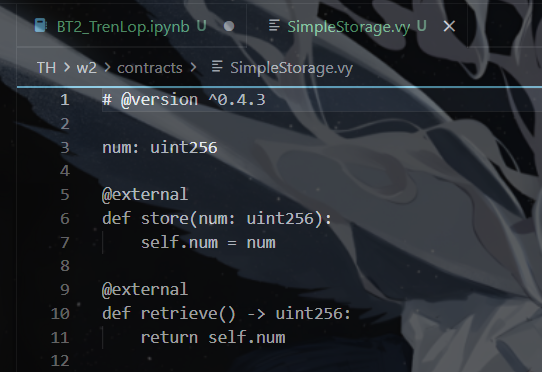

#### Biên dịch contract — `ape compile`

```python
# Chay trong TH/w2 (co contracts/SimpleStorage.vy)
!ape compile
```

```
SUCCESS:  'local project' compiled.
```

## iii. Account alias trên Ganache → lỗi `invalid opcode`

> Chạy ở **terminal**.

### Lệnh (PowerShell)

```python
cd D:\Study\IS355\TH\w2
D:\Study\IS355\.venv-ape\Scripts\ape.exe accounts import is355_
```

Private key **INDEX 4**

Address: `0x4331381a3254dF46ff30D0CFF70c78EE159398F9`

Khi `ape accounts import is355_` hỏi, nhập lần lượt:

Kết quả import trên máy (address INDEX 4):

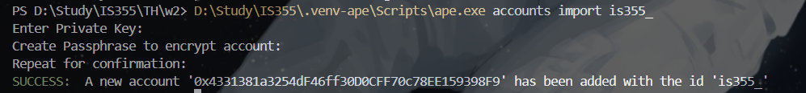

> Alias đang dùng: **`is355_`** — trong `deploy.py` gọi `accounts.load("is355_")`.

Kiểm tra:

```python
D:\Study\IS355\.venv-ape\Scripts\ape.exe accounts list
```

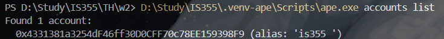

> Alias: `is355_` — address INDEX 4.

Sau khi import, nếu **deploy/gọi contract trên Ganache** có thể gặp:

`VM Exception while processing transaction: invalid opcode`

**Giải thích ngắn (ghi vào báo cáo):**

- Ganache (hardfork / EVM) đôi khi **không khớp** bytecode Vyper 0.4.x (opcode mới).
- Cách xử lý trong lab: chuyển sang **Geth `--dev`** để deploy / test (phần C).

```python
# Chi copy lenh nay sang PowerShell (dung chay ape accounts import bang ! o day)
print(r'''
cd D:\Study\IS355\TH\w2
D:\Study\IS355\.venv-ape\Scripts\Activate.ps1
ape accounts import is355_

# Sau do:
# 1) dan private key INDEX 4 (Ganache)
# 2) dat passphrase (vd 1234567890)
# 3) ape accounts list
''')
```

# C — Geth (Windows)

Phần này dùng Geth thay Ganache để deploy/test Ape ổn định hơn.  
**Không kèm ảnh mẫu đề** — tự chạy rồi chụp kết quả máy bạn.

Dùng CLI: `D:\Study\IS355\.venv-ape\Scripts\ape.exe` (Python 3.12).

## i. Cài Geth & chạy node `--dev`

### Cách làm

1. Geth đã cài tại `D:\Tools\Geth\geth.exe` (v1.17.7).
2. Kiểm tra version:

```
D:\Tools\Geth\geth.exe version
```

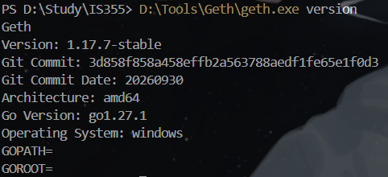

3. Chạy node (**giữ cửa sổ này mở**). Nếu lỗi IPC pipe thì thêm `--ipcdisable`:

```
D:\Tools\Geth\geth.exe --dev --http --http.api eth,web3,net --http.addr 127.0.0.1 --http.port 8545 --ipcdisable
```

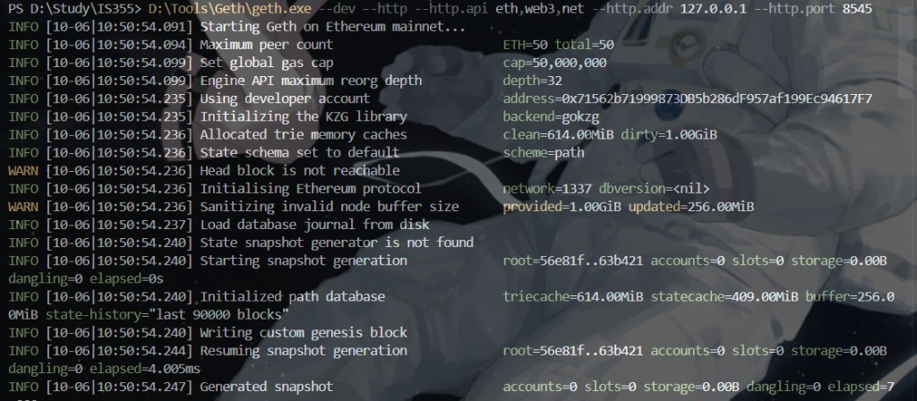

> Network ID `1337`, HTTP port **8545**, account dev: `0x71562b71999873DB5b286dF957af199Ec94617F7`.

### Attach console (terminal thứ 2 — đừng tắt cửa sổ Geth)

```
D:\Tools\Geth\geth.exe attach http://127.0.0.1:8545
```

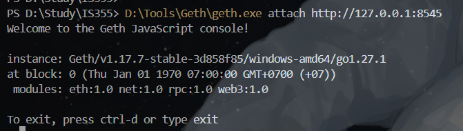

Trong console Geth (prompt `>`), chạy:

```
eth.accounts
web3.fromWei(eth.getBalance(eth.accounts[0]), "ether")
```

Chụp địa chỉ `eth.accounts[0]` + số dư.

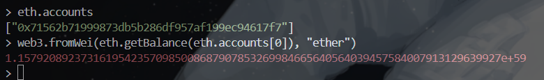

> --dev cấp sẵn balance rất lớn cho account[0] — bình thường.

## ii. Tạo account (`clef`) + chuyển ETH

### Cách làm

```
cd D:\Study\IS355\TH\w2
mkdir my_keystore
clef newaccount --keystore my_keystore
```

- Đặt password và **nhớ**.
- Ghi báo cáo: địa chỉ mới + tên file `UTC--...` trong `my_keystore/`.

Trong `geth attach` (thay `0xDIA_CHI_MOI`):

```
eth.sendTransaction({
  from: eth.accounts[0],
  to: "0xDIA_CHI_MOI",
  value: web3.toWei(10, "ether")
})
web3.fromWei(eth.getBalance("0xDIA_CHI_MOI"), "ether")
```

Chụp: tạo account + send + balance.

## iii. Script `send_eth_on_geth.py`

### Cách làm

1. Chạy cell dưới → tạo file `send_eth_on_geth.py` (HTTP Windows, không IPC).
2. Sửa `password` / keystore nếu khác máy bạn.
3. Chạy (Geth đang mở):

```
cd D:\Study\IS355\TH\w2
D:\Study\IS355\.venv-ape\Scripts\python.exe send_eth_on_geth.py
```

4. Báo cáo: số ETH chuyển + phí (`gasUsed * gasPrice`). Chụp output.

Ket qua chay (2 ETH, gasUsed=21000):

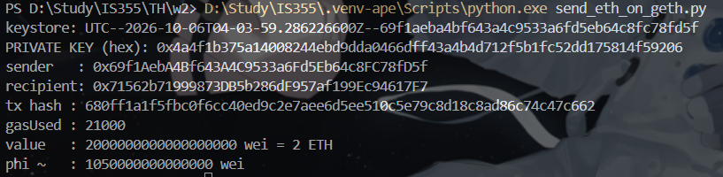

```python
from pathlib import Path
out = Path('send_eth_on_geth.py')
out.parent.mkdir(parents=True, exist_ok=True)
out.write_text('"""Chuyen ETH tren Geth (Windows: HTTP)."""\nfrom pathlib import Path\nfrom web3 import Web3\n\nw3 = Web3(Web3.HTTPProvider("http://127.0.0.1:8545"))\nassert w3.is_connected(), "Mo Geth --dev --http truoc"\n\nkeystore_dir = Path("my_keystore")\nfiles = sorted(keystore_dir.glob("UTC--*"))\nassert files, "Chua co file trong my_keystore/"\nkeystore_path = files[0]\npassword = "1234567890"  # doi dung password clef cua ban\n\nencrypted_key = keystore_path.read_text(encoding="utf-8")\nsender_private_key = w3.eth.account.decrypt(encrypted_key, password)\nprint("PRIVATE KEY (hex): 0x" + sender_private_key.hex())\n\nsender_address = w3.eth.account.from_key(sender_private_key).address\nrecipient_address = Web3.to_checksum_address(w3.eth.accounts[0])\n\namount = Web3.to_wei(2, "ether")\ntransaction = {\n    "chainId": w3.eth.chain_id,\n    "from": sender_address,\n    "to": recipient_address,\n    "value": amount,\n    "gas": 21000,\n    "gasPrice": Web3.to_wei("50", "gwei"),\n    "nonce": w3.eth.get_transaction_count(sender_address),\n}\n\nsigned = w3.eth.account.sign_transaction(transaction, sender_private_key)\nraw = getattr(signed, "raw_transaction", None) or signed.rawTransaction\ntx_hash = w3.eth.send_raw_transaction(raw)\nreceipt = w3.eth.wait_for_transaction_receipt(tx_hash)\n\nprint("tx hash :", tx_hash.hex())\nprint("gasUsed :", receipt["gasUsed"])\nprint("value   :", amount, "wei =", w3.from_wei(amount, "ether"), "ETH")\nprint("phi ~   :", receipt["gasUsed"] * transaction["gasPrice"], "wei")\n', encoding='utf-8')
print('Wrote', out.resolve())
print('Chay: D:\\Study\\IS355\\.venv-ape\\Scripts\\python.exe send_eth_on_geth.py')
```

### (Tuỳ chọn) Import alias Ape từ key Geth

Account Ganache `is355_` **không có ETH trên Geth**. Muốn deploy bằng account keystore:

```
cd D:\Study\IS355\TH\w2
D:\Study\IS355\.venv-ape\Scripts\ape.exe accounts delete is355_ --yes
D:\Study\IS355\.venv-ape\Scripts\ape.exe accounts import is355_
```

Dán private key script vừa in + passphrase `1234567890`.  
Hoặc fund ETH từ `eth.accounts[0]` sang địa chỉ Ganache rồi giữ alias cũ.

## iv. Deploy `SimpleStorage` trên Geth bằng Ape

### Cách làm

1. Cell dưới tạo `scripts/deploy.py`.
2. Kiểm tra: `contracts/SimpleStorage.vy` có sẵn, Geth chạy `:8545`, alias `is355_` có ETH.
3. Chạy:

```
cd D:\Study\IS355\TH\w2
D:\Study\IS355\.venv-ape\Scripts\ape.exe compile
D:\Study\IS355\.venv-ape\Scripts\ape.exe run deploy --network ethereum:local:http://127.0.0.1:8545
```

4. Chụp: địa chỉ contract + Stored / Retrieved.

Compile OK:

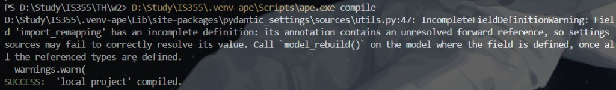

Deploy OK (Stored/Retrieved = 42):

[figure not shown]

```python
from pathlib import Path
out = Path('scripts/deploy.py')
out.parent.mkdir(parents=True, exist_ok=True)
out.write_text('from ape import accounts, project\n\n\ndef main():\n    dev = accounts.load("is355_")\n    dev.set_autosign(True, passphrase="1234567890")  # dung passphrase cua ban\n\n    contract = project.SimpleStorage.deploy(sender=dev)\n    print(f"Deployed at {contract.address}")\n\n    tx = contract.store(42, sender=dev)\n    print("Stored value 42")\n\n    value = contract.retrieve.call()\n    print(f"Retrieved value = {value}")\n', encoding='utf-8')
print('Wrote', out.resolve())
print('Chay: ape run deploy --network ethereum:local:http://127.0.0.1:8545')
```

```python
print("PowerShell:")
print(r"  cd D:\Study\IS355\TH\w2")
print(r"  D:\Study\IS355\.venv-ape\Scripts\ape.exe compile")
print(r"  D:\Study\IS355\.venv-ape\Scripts\ape.exe run deploy --network ethereum:local:http://127.0.0.1:8545")
```

## v. Test `tests/test_simple_storage.py`

### Cách làm

1. Cell dưới tạo file test.
2. Chạy:

```
cd D:\Study\IS355\TH\w2
D:\Study\IS355\.venv-ape\Scripts\ape.exe test
```

3. Chụp kết quả PASSED.

### Giải thích file test

| Thành phần | Vai trò |
| --- | --- |
| `deployer` | `accounts[0]` của môi trường test Ape |
| `contract` | Deploy mới `SimpleStorage` mỗi test |
| `test_retrieve` | Ban đầu `retrieve() == 0` |
| `test_store` | `store(19)` rồi `retrieve() == 19` |
| `.call()` | Đọc state, không tốn gas |
| `sender=...` | Bắt buộc khi ghi state |

Ket qua \ape test\ (**2 passed**):

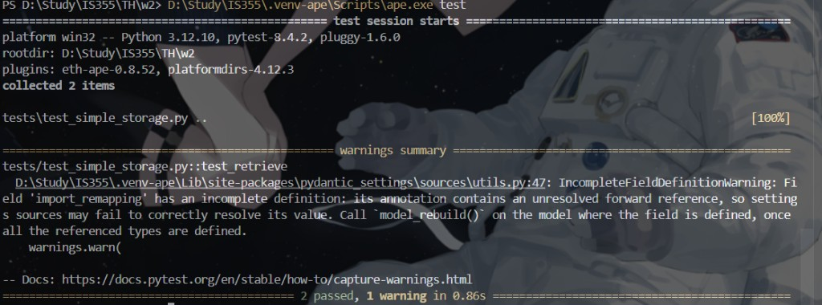

> Warning pydantic bo qua.

```python
from pathlib import Path
out = Path('tests/test_simple_storage.py')
out.parent.mkdir(parents=True, exist_ok=True)
out.write_text('import pytest\n\n\n@pytest.fixture\ndef deployer(accounts):\n    return accounts[0]\n\n\n@pytest.fixture\ndef contract(deployer, project):\n    return deployer.deploy(project.SimpleStorage)\n\n\ndef test_retrieve(contract):\n    num = contract.retrieve.call()\n    assert num == 0\n\n\ndef test_store(contract, deployer):\n    contract.store(19, sender=deployer)\n    num = contract.retrieve.call()\n    assert num == 19\n', encoding='utf-8')
print('Wrote', out.resolve())
print('Chay: D:\\Study\\IS355\\.venv-ape\\Scripts\\ape.exe test')
```